# Diamond Dataset EDA - Week 2 by Kyle Maher

### Setup

```r
library(tidymodels)
library(scales)    # Axis Formatting
library(gt)    # Table Formatting

set.seed(28)

df <- ggplot2::diamonds
```

### Cleaning

```r
# Remove 20 rows with at least one zero dimension
df <- filter(df, x > 0, y > 0, z > 0)
```

### Split Into Train & Test Data

```r
df_split <- initial_split(df)
df_train <- training(df_split)
df_test <- testing(df_split)

df_split
```

```
<Training/Testing/Total>
<40440/13480/53920>
```

# Functions

### Show Coefficients

```r
show_coefficients <- function(model) {
  tidy(model) %>%
  gt() %>%
  tab_options(table.align = "left")
}
```

### Show Summary

```r
show_summary <- function(model) {
  glance(model) %>%
  gt() %>%
  tab_options(table.align = "left")
}
```

### Show Plots

```r
show_plots <- function(model) {
  par(mfrow = c(4,1)) # adjust to show all four model plots
  plot(model)
  par(mfrow = c(1,1)) # reset
}
```

### Show rmse

```r
show_rmse <- function(rmse) {
  tibble(Root_Mean_Squared_Error = rmse) %>%
  gt() %>%
  tab_options(table.align = "left")
}
```

# Model Version #1 (Basic)

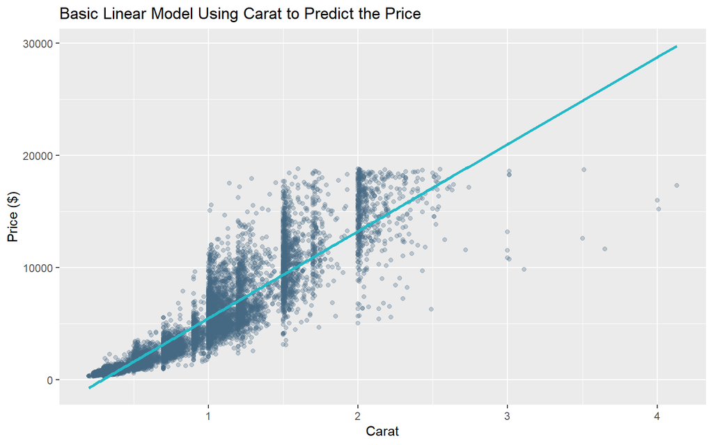

```r
model <- lm(price ~ carat, data = df_train)
df_test$pred <- predict(model, newdata = df_test)

df_test %>%
  ggplot(aes(x = carat, y = price)) +
  geom_point(color = "#456882", alpha = .3) +
  geom_line(aes(y = pred), color = "#25b9c7", linewidth = 1.2) +
  labs(
    x = "Carat",
    y = "Price ($)",
    title = "Basic Linear Model Using Carat to Predict the Price")
```

This obviously is not the best fit. However, lets define how poor it actually is.

```r
show_coefficients(model)
```

| term | estimate | std.error | statistic | p.value |
| --- | --- | --- | --- | --- |
| (Intercept) | -2254.987 | 15.03722 | -149.9604 | 0 |
| carat | 7749.773 | 16.25453 | 476.7761 | 0 |

```r
show_summary(model)
```

| r.squared | adj.r.squared | sigma | statistic | p.value | df | logLik | AIC | BIC | deviance | df.residual | nobs |
| --- | --- | --- | --- | --- | --- | --- | --- | --- | --- | --- | --- |
| 0.848973 | 0.8489693 | 1546.164 | 227315.4 | 0 | 1 | -354353.3 | 708712.6 | 708738.5 | 9.6672e+10 | 40438 | 40440 |

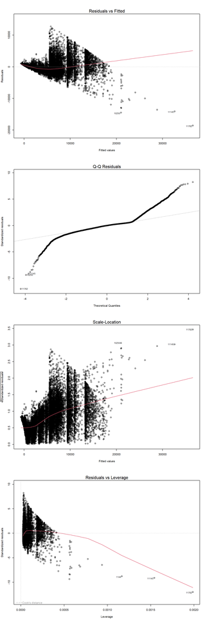

```r
show_plots(model)
```

```r
rmse <- sqrt(mean((df_test$price - df_test$pred)^2))
show_rmse(rmse)
```

| Root_Mean_Squared_Error |
| --- |
| 1552.396 |

Well, it looks like there are a lot of things wrong here. Most of the red lines are not close to horizontal and the Q-Q plot has some extreme tails. Not to mention the large RMSE.

# Model Version #2 (Log Scale)

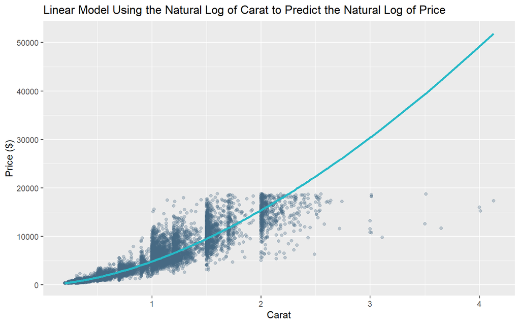

```r
model <- lm(log(price) ~ log(carat), data = df_train)

# See (1) for log backwards conversion formula
df_test$pred <- exp(predict(model, df_test) + summary(model)$sigma^2 / 2)

df_test %>%
  ggplot(aes(x = carat, y = price)) +
  geom_point(color = "#456882", alpha = .3) +
  geom_line(aes(y = pred), color = "#25b9c7", linewidth = 1.2) +
  labs(
    x = "Carat",
    y = "Price ($)",
    title = "Linear Model Using the Natural Log of Carat to Predict the Natural Log of Price")
```

Finding the linear model at the log scale gives it a curved fit once the reverse transformation is done. This enables it to better follow the distribution.

```r
show_coefficients(model)
```

| term | estimate | std.error | statistic | p.value |
| --- | --- | --- | --- | --- |
| (Intercept) | 8.447025 | 0.001580803 | 5343.5028 | 0 |
| log(carat) | 1.674577 | 0.002231835 | 750.3139 | 0 |

```r
show_summary(model)
```

| r.squared | adj.r.squared | sigma | statistic | p.value | df | logLik | AIC | BIC | deviance | df.residual | nobs |
| --- | --- | --- | --- | --- | --- | --- | --- | --- | --- | --- | --- |
| 0.9329841 | 0.9329824 | 0.2626561 | 562971 | 0 | 1 | -3316.251 | 6638.502 | 6664.325 | 2789.747 | 40438 | 40440 |

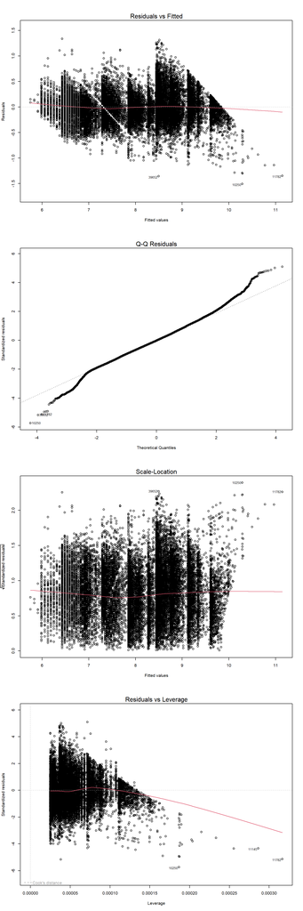

```r
show_plots(model)
```

```r
rmse <- sqrt(mean((df_test$price - df_test$pred)^2))
show_rmse(rmse)
```

| Root_Mean_Squared_Error |
| --- |
| 1721.216 |

# Splitting Up The Model

### Where To Split

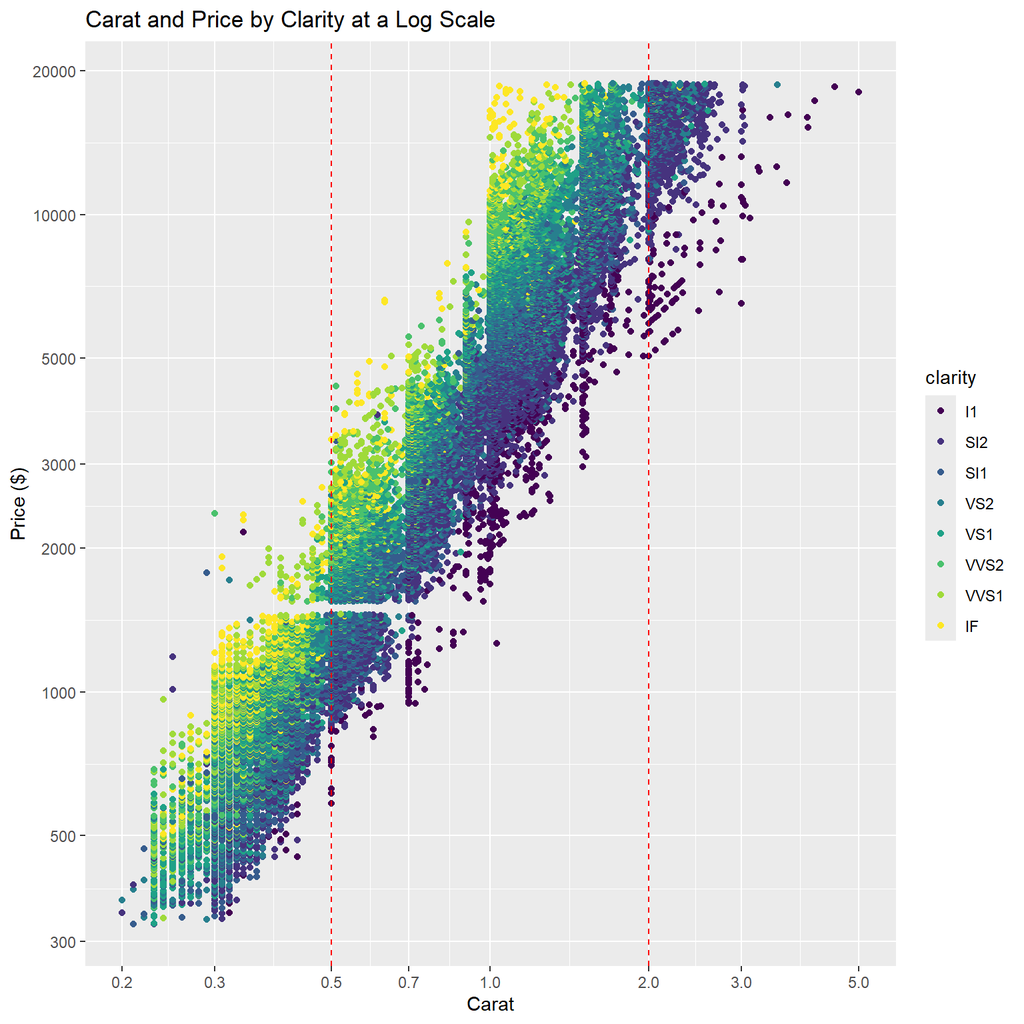

```r
df %>%
  ggplot(aes(x = carat, y = price, color = clarity)) +
  geom_point() +
  scale_x_log10(breaks = scales::log_breaks(n = 10)) +
  scale_y_log10(breaks = scales::log_breaks(n = 10)) +
  geom_vline(xintercept = c(.5, 2), color = "red", linetype = "dashed") +
  labs(
    x = "Carat",
    y = "Price ($)",
    title = "Carat and Price by Clarity at a Log Scale"
  )
```

The splits .5 and 2 Carats were chosen based on general break points.

### New Train & Test Data Splits

```r
df_small <- filter(df, carat < .5)
df_medium <- filter(df, carat >= .5 & carat < 2)
df_large <- filter(df, carat >= 2)

df_small_split <- initial_split(df_small)
df_small_train <- training(df_small_split)
df_small_test <- testing(df_small_split)

df_medium_split <- initial_split(df_medium)
df_medium_train <- training(df_medium_split)
df_medium_test <- testing(df_medium_split)

df_large_split <- initial_split(df_large)
df_large_train <- training(df_large_split)
df_large_test <- testing(df_large_split)
```

# Model Version #3 (Split & Log Scale)

### Small Diamonds

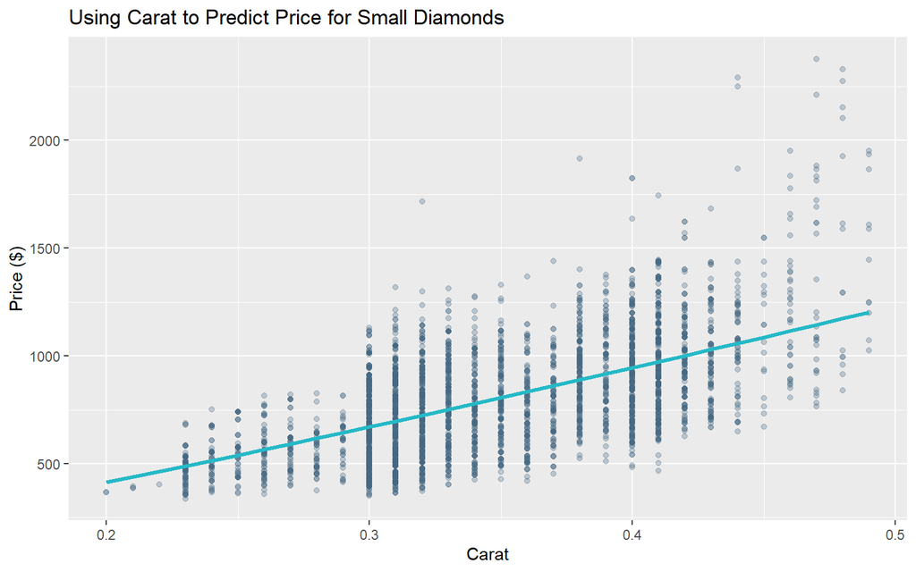

```r
model <- lm(log(price) ~ log(carat), data = df_small_train)

df_small_test$pred <- exp(
  predict(model, df_small_test) + summary(model)$sigma^2 / 2)

df_small_test %>%
  ggplot(aes(x = carat, y = price)) +
  geom_point(color = "#456882", alpha = .3) +
  geom_line(aes(y = pred), color = "#25b9c7", linewidth = 1.2) +
  labs(
    x = "Carat",
    y = "Price ($)",
    title = "Using Carat to Predict Price for Small Diamonds")
```

Under .5 Carats the Carat almost acts as a categorical variable due to the very distinct levels. In theory converting it to a factor may improve the results, but lets keep moving.

```r
show_coefficients(model)
```

| term | estimate | std.error | statistic | p.value |
| --- | --- | --- | --- | --- |
| (Intercept) | 7.913997 | 0.01427789 | 554.28321 | 0 |
| log(carat) | 1.191059 | 0.01311144 | 90.84119 | 0 |

```r
show_summary(model)
```

| r.squared | adj.r.squared | sigma | statistic | p.value | df | logLik | AIC | BIC | deviance | df.residual | nobs |
| --- | --- | --- | --- | --- | --- | --- | --- | --- | --- | --- | --- |
| 0.3837282 | 0.3836817 | 0.2373798 | 8252.122 | 0 | 1 | 254.9053 | -503.8105 | -481.3342 | 746.7954 | 13253 | 13255 |

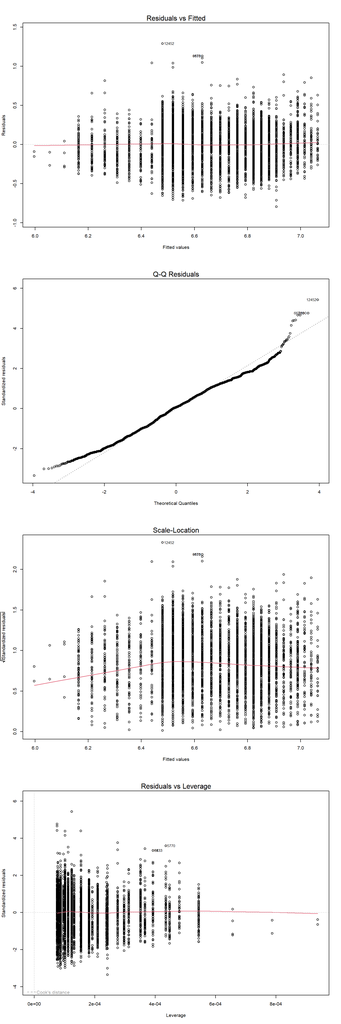

```r
show_plots(model)
```

```r
rmse <- sqrt(mean((df_small_test$price - df_small_test$pred)^2))
show_rmse(rmse)
```

| Root_Mean_Squared_Error |
| --- |
| 193.9803 |

Even with the almost discrete nature, this model was able to predict the diamond Price within about $194 for diamonds less than .5 Carats only using the Carat.

### Medium Diamonds

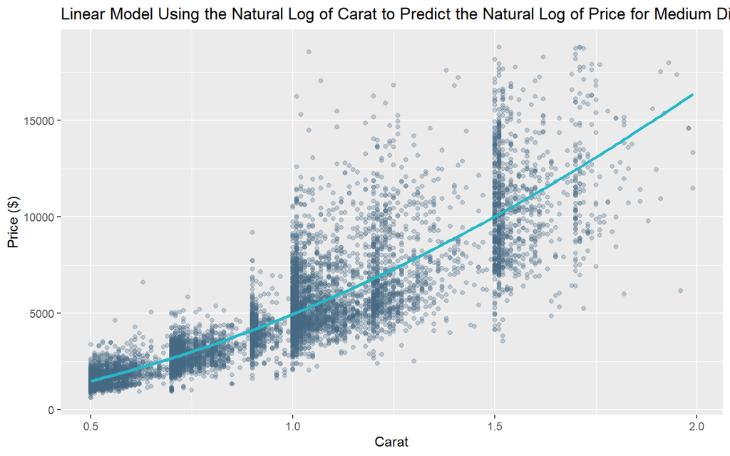

```r
model <- lm(log(price) ~ log(carat), data = df_medium_train)
df_medium_test$pred <- exp(
  predict(model, df_medium_test) + summary(model)$sigma^2 / 2)

df_medium_test %>%
  ggplot(aes(x = carat, y = price)) +
  geom_point(color = "#456882", alpha = .3) +
  geom_line(aes(y = pred), color = "#25b9c7", linewidth = 1.2) +
  labs(
    x = "Carat",
    y = "Price ($)",
    title = "Linear Model Using the Natural Log of Carat to Predict the Natural Log of Price for Medium Diamonds")
```

This line looks pretty good, however there is some significant variation in price at the same carat which may hinder the model performance.

```r
show_coefficients(model)
```

| term | estimate | std.error | statistic | p.value |
| --- | --- | --- | --- | --- |
| (Intercept) | 8.470972 | 0.001757063 | 4821.0966 | 0 |
| log(carat) | 1.737863 | 0.004750738 | 365.8091 | 0 |

```r
show_summary(model)
```

| r.squared | adj.r.squared | sigma | statistic | p.value | df | logLik | AIC | BIC | deviance | df.residual | nobs |
| --- | --- | --- | --- | --- | --- | --- | --- | --- | --- | --- | --- |
| 0.8395669 | 0.8395606 | 0.2672787 | 133816.3 | 0 | 1 | -2542.875 | 5091.75 | 5116.197 | 1826.738 | 25571 | 25573 |

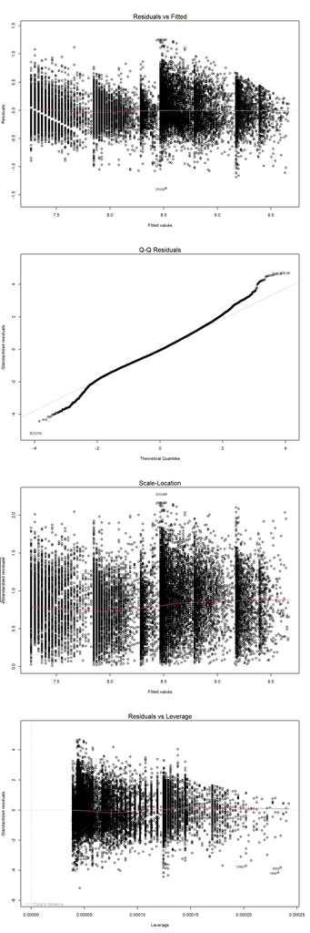

```r
show_plots(model)
```

```r
rmse <- sqrt(mean((df_medium_test$price - df_medium_test$pred)^2))
show_rmse(rmse)
```

| Root_Mean_Squared_Error |
| --- |
| 1643.344 |

The extreme variation results in a somewhat poor prediction for medium sized diamonds. Since there is extreme variation in price at the same carat level, adding the categorical variables to the model may improve it significantly.

### Large Diamonds

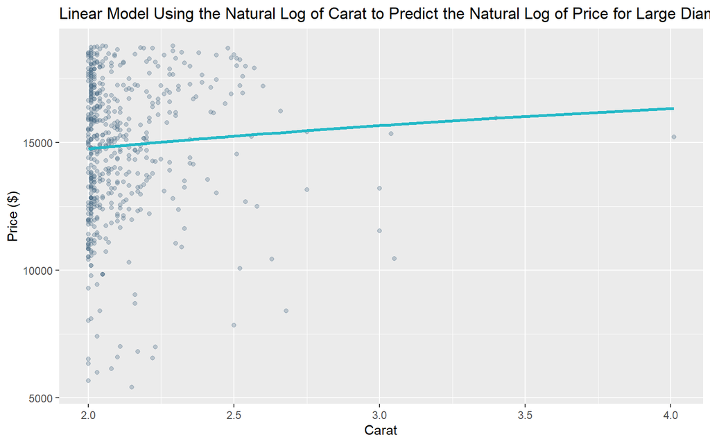

```r
model <- lm(log(price) ~ log(carat), data = df_large_train)

df_large_test$pred <- exp(
  predict(model, df_large_test) + summary(model)$sigma^2 / 2)

df_large_test %>%
  ggplot(aes(x = carat, y = price)) +
  geom_point(color = "#456882", alpha = .3) +
  geom_line(aes(y = pred), color = "#25b9c7", linewidth = 1.2) +
  labs(
    x = "Carat",
    y = "Price ($)",
    title = "Linear Model Using the Natural Log of Carat to Predict the Natural Log of Price for Large Diamonds")
```

Woah there. This does not look like a good case for a linear model.

```r
show_coefficients(model)
```

| term | estimate | std.error | statistic | p.value |
| --- | --- | --- | --- | --- |
| (Intercept) | 9.4739098 | 0.04354947 | 217.543613 | 0.00000000 |
| log(carat) | 0.1474736 | 0.05720113 | 2.578158 | 0.01002106 |

```r
show_summary(model)
```

| r.squared | adj.r.squared | sigma | statistic | p.value | df | logLik | AIC | BIC | deviance | df.residual | nobs |
| --- | --- | --- | --- | --- | --- | --- | --- | --- | --- | --- | --- |
| 0.00411408 | 0.003495133 | 0.2166625 | 6.646901 | 0.01002106 | 1 | 178.977 | -351.954 | -335.8002 | 75.53073 | 1609 | 1611 |

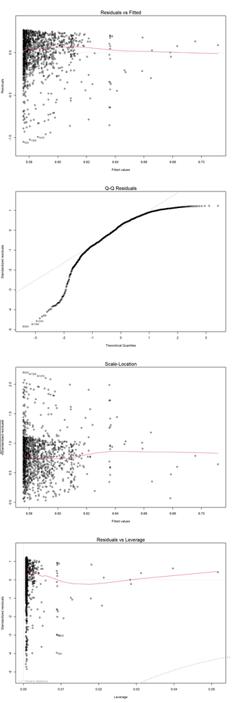

```r
show_plots(model)
```

```r
rmse <- sqrt(mean((df_large_test$price - df_large_test$pred)^2))
show_rmse(rmse)
```

| Root_Mean_Squared_Error |
| --- |
| 2715.613 |

The diagnostic plots confirm that less data and a non visable linear relationship here makes this model quite poor. Lets focus on the small and medium sized diamonds limiting the size to under 2 carats.

# Model Version 4 (Split & Log Scale & Categorical Parameters)

### Small Diamonds

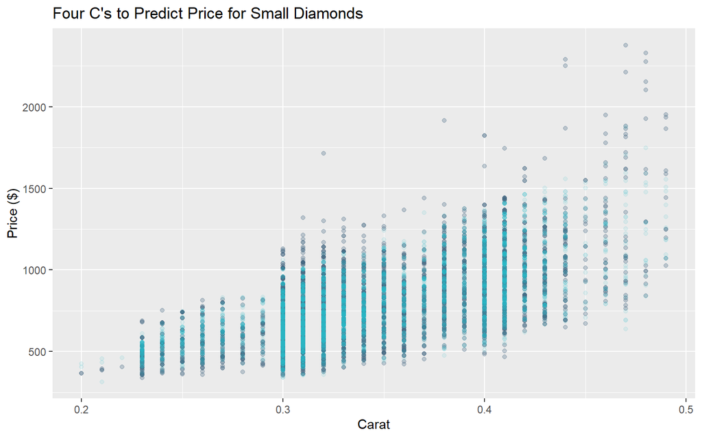

```r
model <- lm(log(price) ~ log(carat) + clarity + color + cut, data = df_small_train)

df_small_test$pred <- exp(
  predict(model, df_small_test) + summary(model)$sigma^2 / 2)

df_small_test %>%
  ggplot(aes(x = carat, y = price)) +
  geom_point(color = "#456882", alpha = .3) +
  geom_point(aes(y = pred), color = "#25b9c7", alpha = .1) +
  labs(
    x = "Carat",
    y = "Price ($)",
    title = "Four C's to Predict Price for Small Diamonds")
```

Adding the categorical variables causes this to no longer be a simple linear model. As a result we would expect the correlation to improve drasticly.

```r
show_coefficients(model)
```

| term | estimate | std.error | statistic | p.value |
| --- | --- | --- | --- | --- |
| (Intercept) | 7.979398215 | 0.009026044 | 884.0415464 | 0.000000e+00 |
| log(carat) | 1.378418878 | 0.007305658 | 188.6782550 | 0.000000e+00 |
| clarity.L | 0.724174284 | 0.015904260 | 45.5333523 | 0.000000e+00 |
| clarity.Q | -0.074806246 | 0.015752487 | -4.7488530 | 2.067189e-06 |
| clarity.C | 0.014669319 | 0.012733646 | 1.1520124 | 2.493368e-01 |
| clarity^4 | 0.027766656 | 0.008784352 | 3.1609225 | 1.576249e-03 |
| clarity^5 | -0.031916212 | 0.005434514 | -5.8728738 | 4.385836e-09 |
| clarity^6 | 0.003396417 | 0.003456065 | 0.9827409 | 3.257530e-01 |
| clarity^7 | 0.022803912 | 0.002683709 | 8.4971615 | 2.148901e-17 |
| color.L | -0.429337732 | 0.004792249 | -89.5900371 | 0.000000e+00 |
| color.Q | -0.084722030 | 0.004508298 | -18.7924647 | 8.926012e-78 |
| color.C | -0.011096431 | 0.004033515 | -2.7510577 | 5.948394e-03 |
| color^4 | 0.012091840 | 0.003474594 | 3.4800729 | 5.028914e-04 |
| color^5 | 0.002504757 | 0.003154540 | 0.7940166 | 4.272000e-01 |
| color^6 | 0.002312288 | 0.002724583 | 0.8486758 | 3.960771e-01 |
| cut.L | 0.042693132 | 0.009114784 | 4.6839436 | 2.842060e-06 |
| cut.Q | 0.055716298 | 0.007823117 | 7.1220077 | 1.118607e-12 |
| cut.C | -0.086640086 | 0.005458199 | -15.8733834 | 3.195591e-56 |
| cut^4 | -0.038436130 | 0.003415515 | -11.2533924 | 3.025503e-29 |

```r
show_summary(model)
```

| r.squared | adj.r.squared | sigma | statistic | p.value | df | logLik | AIC | BIC | deviance | df.residual | nobs |
| --- | --- | --- | --- | --- | --- | --- | --- | --- | --- | --- | --- |
| 0.8204785 | 0.8202344 | 0.1282019 | 3360.741 | 0 | 18 | 8429.219 | -16818.44 | -16668.6 | 217.5433 | 13236 | 13255 |

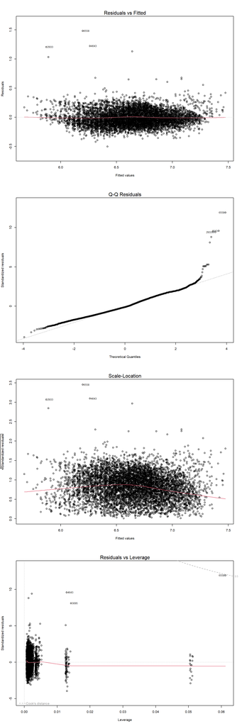

```r
show_plots(model)
```

```r
rmse <- sqrt(mean((df_small_test$price - df_small_test$pred)^2))
show_rmse(rmse)
```

| Root_Mean_Squared_Error |
| --- |
| 105.8284 |

Yes, we are able to predict the price to within about $106 for Small Diamonds on average.

### Medium Diamonds

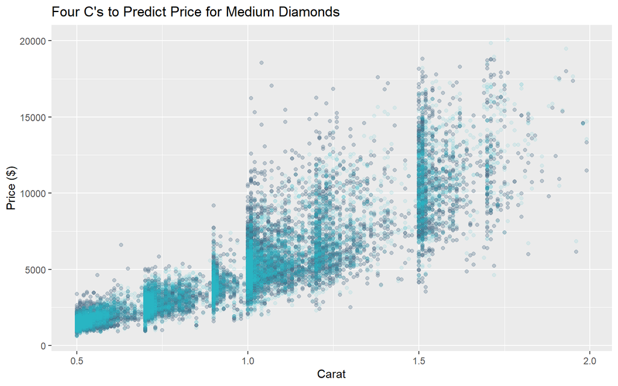

```r
model <- lm(log(price) ~ log(carat) + clarity + color + cut, data = df_medium_train)
df_medium_test$pred <- exp(
  predict(model, df_medium_test) + summary(model)$sigma^2 / 2)

df_medium_test %>%
  ggplot(aes(x = carat, y = price)) +
  geom_point(color = "#456882", alpha = .3) +
  geom_point(aes(y = pred), color = "#25b9c7", alpha = .1) +
  labs(
    x = "Carat",
    y = "Price ($)",
    title = "Four C's to Predict Price for Medium Diamonds")
```

We would expect a better correlation here as well.

```r
show_coefficients(model)
```

| term | estimate | std.error | statistic | p.value |
| --- | --- | --- | --- | --- |
| (Intercept) | 8.472276362 | 0.001461528 | 5796.863213 | 0.000000e+00 |
| log(carat) | 1.946553488 | 0.002237492 | 869.970969 | 0.000000e+00 |
| clarity.L | 0.910368088 | 0.004766595 | 190.989167 | 0.000000e+00 |
| clarity.Q | -0.224320276 | 0.004510679 | -49.730933 | 0.000000e+00 |
| clarity.C | 0.109049382 | 0.003951640 | 27.595978 | 3.289869e-165 |
| clarity^4 | -0.060553703 | 0.003292588 | -18.390912 | 4.741829e-75 |
| clarity^5 | 0.027540132 | 0.002751180 | 10.010298 | 1.517718e-23 |
| clarity^6 | 0.009609196 | 0.002326057 | 4.131110 | 3.621647e-05 |
| clarity^7 | 0.031858018 | 0.001917784 | 16.611889 | 1.204182e-61 |
| color.L | -0.455389254 | 0.002529034 | -180.064537 | 0.000000e+00 |
| color.Q | -0.096608578 | 0.002326115 | -41.532154 | 0.000000e+00 |
| color.C | -0.009809832 | 0.002199902 | -4.459213 | 8.261142e-06 |
| color^4 | 0.017047308 | 0.002046355 | 8.330571 | 8.444168e-17 |
| color^5 | -0.004226729 | 0.001923012 | -2.197973 | 2.795997e-02 |
| color^6 | 0.002099278 | 0.001750096 | 1.199522 | 2.303362e-01 |
| cut.L | 0.121306883 | 0.002678300 | 45.292489 | 0.000000e+00 |
| cut.Q | -0.030763807 | 0.002393821 | -12.851338 | 1.106191e-37 |
| cut.C | 0.035591181 | 0.002135963 | 16.662823 | 5.191683e-62 |
| cut^4 | 0.016480758 | 0.001762875 | 9.348794 | 9.567782e-21 |

```r
show_summary(model)
```

| r.squared | adj.r.squared | sigma | statistic | p.value | df | logLik | AIC | BIC | deviance | df.residual | nobs |
| --- | --- | --- | --- | --- | --- | --- | --- | --- | --- | --- | --- |
| 0.9687576 | 0.9687356 | 0.1179869 | 44020.75 | 0 | 18 | 18377.14 | -36714.28 | -36551.3 | 355.7348 | 25554 | 25573 |

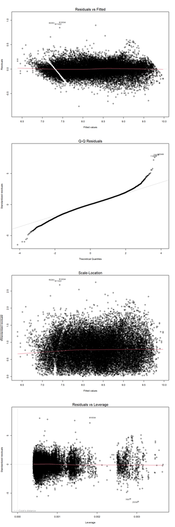

```r
show_plots(model)
```

```r
rmse <- sqrt(mean((df_medium_test$price - df_medium_test$pred)^2))
show_rmse(rmse)
```

| Root_Mean_Squared_Error |
| --- |
| 715.2202 |

# Back To One Model

### Dropping Large Values

```r
cap = 2
df_capped <- filter(df, carat <= cap)

df_split <- initial_split(df_capped)
df_train <- training(df_split)
df_test <- testing(df_split)
```

# Model Version #5 (Log Scale & Categorical Parameters & Capped Carat Size)

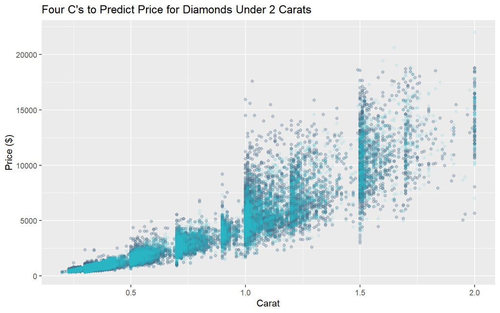

```r
model <- lm(log(price) ~ log(carat) +
  color + cut + clarity, data = df_train)

df_test$pred <- exp(
  predict(model, df_test) + summary(model)$sigma^2 / 2)

df_test %>%
  ggplot(aes(x = carat, y = price)) +
  geom_point(color = "#456882", alpha = .3) +
  geom_point(aes(y = pred), color = "#25b9c7", alpha = .1) +
  labs(
    x = "Carat",
    y = "Price ($)",
    title = paste("Four C's to Predict Price for Diamonds Under", cap, "Carats"))
```

These predictions look quite good, but perhaps subject to overfitting.

```r
show_coefficients(model)
```

| term | estimate | std.error | statistic | p.value |
| --- | --- | --- | --- | --- |
| (Intercept) | 8.4669821380 | 0.001400897 | 6043.97383408 | 0.000000e+00 |
| log(carat) | 1.8908563404 | 0.001348136 | 1402.57072135 | 0.000000e+00 |
| color.L | -0.4384929651 | 0.002383146 | -183.99754730 | 0.000000e+00 |
| color.Q | -0.0943794959 | 0.002212800 | -42.65161999 | 0.000000e+00 |
| color.C | -0.0132793291 | 0.002062571 | -6.43824235 | 1.222665e-10 |
| color^4 | 0.0137867074 | 0.001886154 | 7.30942952 | 2.734131e-13 |
| color^5 | -0.0006587587 | 0.001769239 | -0.37234021 | 7.096416e-01 |
| color^6 | 0.0017391644 | 0.001593453 | 1.09144393 | 2.750843e-01 |
| cut.L | 0.1204918074 | 0.002729975 | 44.13659667 | 0.000000e+00 |
| cut.Q | -0.0311158935 | 0.002401581 | -12.95641942 | 2.592975e-38 |
| cut.C | 0.0103211965 | 0.002082851 | 4.95532180 | 7.251261e-07 |
| cut^4 | -0.0003912555 | 0.001668611 | -0.23447979 | 8.146138e-01 |
| clarity.L | 0.8949920616 | 0.004225872 | 211.78875378 | 0.000000e+00 |
| clarity.Q | -0.2179366281 | 0.003966771 | -54.94055714 | 0.000000e+00 |
| clarity.C | 0.1109633901 | 0.003384419 | 32.78654112 | 1.336951e-232 |
| clarity^4 | -0.0528129209 | 0.002688557 | -19.64359180 | 1.700975e-85 |
| clarity^5 | 0.0189473858 | 0.002166131 | 8.74710819 | 2.274685e-18 |
| clarity^6 | -0.0001205286 | 0.001863563 | -0.06467643 | 9.484320e-01 |
| clarity^7 | 0.0332776142 | 0.001643420 | 20.24900391 | 1.062312e-90 |

```r
show_summary(model)
```

| r.squared | adj.r.squared | sigma | statistic | p.value | df | logLik | AIC | BIC | deviance | df.residual | nobs |
| --- | --- | --- | --- | --- | --- | --- | --- | --- | --- | --- | --- |
| 0.9816212 | 0.9816127 | 0.1317789 | 115746.3 | 0 | 18 | 23725.86 | -47411.71 | -47240.27 | 677.4008 | 39008 | 39027 |

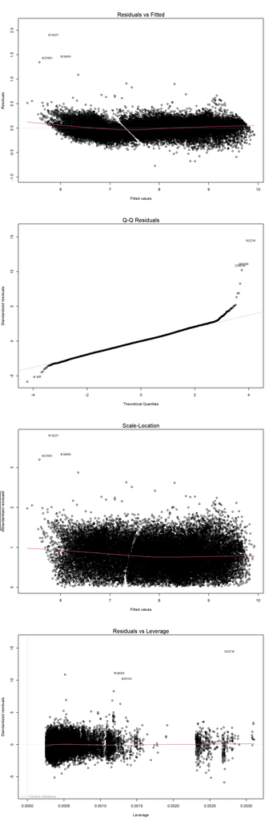

```r
show_plots(model)
```

```r
rmse <- sqrt(mean((df_test$price - df_test$pred)^2))
show_rmse(rmse)
```

| Root_Mean_Squared_Error |
| --- |
| 610.6686 |

```r
# Training RMSE to test for overfitting
df_train$pred <- exp(
  predict(model, df_train) + summary(model)$sigma^2 / 2)

rmse <- sqrt(mean((df_train$price - df_train$pred)^2))
show_rmse(rmse)
```

| Root_Mean_Squared_Error |
| --- |
| 622.7129 |

Since the rmse for the Training and Testing data are similar it is unlikely that the model is overfit. It is likely that this model can actually predict the diamond price within around $610 on average.

# Conclusions

For diamonds less than 2 carats, a model with an R Squared of .98 was reached which is able to predict the diamond price using Carat, Clarity, Color, and Cut with a RMSE of $610.

For diamonds smaller than .5 Carats model version 4 was able to predict the price with a RMSE of $106.

### Unanswered Questions:

There appears to be a price where no diamonds are for sale around $1500.

# References

### (1) Reverse Transformation For The Mean For Log Transformed Data

https://stats.stackexchange.com/questions/359088/correcting-log-transformation-bias-in-a-linear-model

E(Y) = e^(mu + sigma^2 / 2)